# DATA 605 Final Project

Dominika Markowska-Desvallons

5/24/2021

```r
library(gridExtra)
library(RColorBrewer)
library(Matrix)
library(scales)
library(corrplot)
library(MASS)
library(psych)
library(ggplot2)
library(matlib)
library(dplyr)
library(tidyr)
library(kableExtra)
library(purrr)
library(Hmisc)
```

## Problem 1

Using R, generate a random variable X that has 10,000 random uniform numbers from 1 to N, where N can be any number of your choosing greater than or equal to 6. Then generate a random variable Y that has 10,000 random normal numbers with a mean of
$$\mu=\sigma=(N+1)/2$$
.
a. P(X>x | X>y) b. P(X>x, Y>y) c. P(X<x | X>y)
Investigate whether P(X>x and Y>y)=P(X>x)P(Y>y) by building a table and evaluating the marginal and joint probabilities. Check to see if independence holds by using Fisher’s Exact Test and the Chi Square Test. What is the difference between the two? Which is most appropriate?

```r
set.seed(666)
N <- 10
n <- 10000


X <- runif(10000, 1, N)


Y <- rnorm(10000, (N+1)/2, (N+1)/2)
```

### Probability

Assume the small letter “x” is estimated as the median of the X variable, and the small letter “y” is estimated as the 1st quartile of the Y variable.

```r
x <- median(X)
x
```

```
## [1] 5.552747
```

```r
y <- quantile(Y, 0.25)
y
```

```
##      25%
## 1.873373
```

### a. P(X>x | X>y)

```r
pAll<-sum(X>x & X>y)/n
pXy<-sum(X>y)/n


p1=pAll/pXy

round(p1,2)
```

```
## [1] 0.55
```

The probability is 0.55 or 55%.

### b. P(X>x, Y>y)

```r
p2<-(sum(X>x & Y>y))/n
round(p2,2)
```

```
## [1] 0.38
```

### c. P(X<x | X>y)

```r
p3<-sum(X<x & X>y)/n
round(p3,2)
```

```
## [1] 0.41
```

### Next Independence testing

Investigate whether P(X>x and Y>y) = P(X > x) * P(Y > y) by building a table and evaluating the marginal and joint probabilities.

```r
m<-matrix( c(sum(X>x & Y<y),sum(X>x & Y>y), sum(X<x & Y<y),sum(X<x & Y>y)), nrow = 2,ncol = 2)
m<-cbind(m,c(m[1,1]+m[1,2],m[2,1]+m[2,2]))
m<-rbind(m,c(m[1,1]+m[2,1],m[1,2]+m[2,2],m[1,3]+m[2,3]))


df<-as.data.frame(m)
names(df) <- c("X>x","X<x", "Total")
row.names(df) <- c("Y<y","Y>y", "Total")
kable(df)%>%
  kable_styling(bootstrap_options = "bordered")
```

|  | X>x | X<x | Total |
| --- | --- | --- | --- |
| Y<y | 1250 | 1250 | 2500 |
| Y>y | 3750 | 3750 | 7500 |
| Total | 5000 | 5000 | 10000 |

```r
pm<-m/m[3,3]
dfp<-as.data.frame(pm)
names(dfp) <- c("X>x","X<x", "Total")
row.names(dfp) <- c("Y<y","Y>y", "Total")
kable(round(dfp,2)) %>%
  kable_styling(bootstrap_options = "bordered")
```

|  | X>x | X<x | Total |
| --- | --- | --- | --- |
| Y<y | 0.12 | 0.12 | 0.25 |
| Y>y | 0.38 | 0.38 | 0.75 |
| Total | 0.50 | 0.50 | 1.00 |

#### Calculating

```r
#P(X>x)P(Y>y)
p1<-pm[3,1]*pm[2,3]
p1
```

```
## [1] 0.375
```

```r
#P(X>x and Y>y)
p2<-round(pm[2,1],digits = 3)
p2
```

```
## [1] 0.375
```

```r
#P(X>x and Y>y)=P(X>x)P(Y>y)
p1==p2
```

```
## [1] TRUE
```

```r
chisq.test(m, correct=TRUE)
```

```
##
##  Pearson's Chi-squared test
##
## data:  m
## X-squared = 0, df = 4, p-value = 1
```

```r
fisher.test(m, simulate.p.value=TRUE)
```

```
##
##  Fisher's Exact Test for Count Data with simulated p-value (based on
##  2000 replicates)
##
## data:  m
## p-value = 1
## alternative hypothesis: two.sided
```

We use the chi square test is used when the cell sizes are large, which would be appropriate to use in this case.

## Problem Two

You are to register for Kaggle.com (free) and compete in the House Prices: Advanced Regression Techniques competition. https://www.kaggle.com/c/house-prices-advanced-regression-techniques . I want you to do the following.

## Descriptive and Inferential Statistics

```r
train <- read.csv('https://raw.githubusercontent.com/hrensimin05/Data605_FinalProject/main/train.csv')
test<-read.csv('https://raw.githubusercontent.com/hrensimin05/Data605_FinalProject/main/test.csv')

dim(train)
```

```
## [1] 1460   81
```

```r
summary(train)
```

```
##        Id           MSSubClass      MSZoning          LotFrontage
##  Min.   :   1.0   Min.   : 20.0   Length:1460        Min.   : 21.00
##  1st Qu.: 365.8   1st Qu.: 20.0   Class :character   1st Qu.: 59.00
##  Median : 730.5   Median : 50.0   Mode  :character   Median : 69.00
##  Mean   : 730.5   Mean   : 56.9                      Mean   : 70.05
##  3rd Qu.:1095.2   3rd Qu.: 70.0                      3rd Qu.: 80.00
##  Max.   :1460.0   Max.   :190.0                      Max.   :313.00
##                                                      NA's   :259
##     LotArea          Street             Alley             LotShape
##  Min.   :  1300   Length:1460        Length:1460        Length:1460
##  1st Qu.:  7554   Class :character   Class :character   Class :character
##  Median :  9478   Mode  :character   Mode  :character   Mode  :character
##  Mean   : 10517
##  3rd Qu.: 11602
##  Max.   :215245
##
##  LandContour         Utilities          LotConfig          LandSlope
##  Length:1460        Length:1460        Length:1460        Length:1460
##  Class :character   Class :character   Class :character   Class :character
##  Mode  :character   Mode  :character   Mode  :character   Mode  :character
##
##
##
##
##  Neighborhood        Condition1         Condition2          BldgType
##  Length:1460        Length:1460        Length:1460        Length:1460
##  Class :character   Class :character   Class :character   Class :character
##  Mode  :character   Mode  :character   Mode  :character   Mode  :character
##
##
##
##
##   HouseStyle         OverallQual      OverallCond      YearBuilt
##  Length:1460        Min.   : 1.000   Min.   :1.000   Min.   :1872
##  Class :character   1st Qu.: 5.000   1st Qu.:5.000   1st Qu.:1954
##  Mode  :character   Median : 6.000   Median :5.000   Median :1973
##                     Mean   : 6.099   Mean   :5.575   Mean   :1971
##                     3rd Qu.: 7.000   3rd Qu.:6.000   3rd Qu.:2000
##                     Max.   :10.000   Max.   :9.000   Max.   :2010
##
```

[output cut: 113 more lines]

```
##  Min.   : 1.000   Min.   :2006   Length:1460        Length:1460
##  1st Qu.: 5.000   1st Qu.:2007   Class :character   Class :character
##  Median : 6.000   Median :2008   Mode  :character   Mode  :character
##  Mean   : 6.322   Mean   :2008
##  3rd Qu.: 8.000   3rd Qu.:2009
##  Max.   :12.000   Max.   :2010
##
##    SalePrice
##  Min.   : 34900
##  1st Qu.:129975
##  Median :163000
##  Mean   :180921
##  3rd Qu.:214000
##  Max.   :755000
##
```

#### Variables

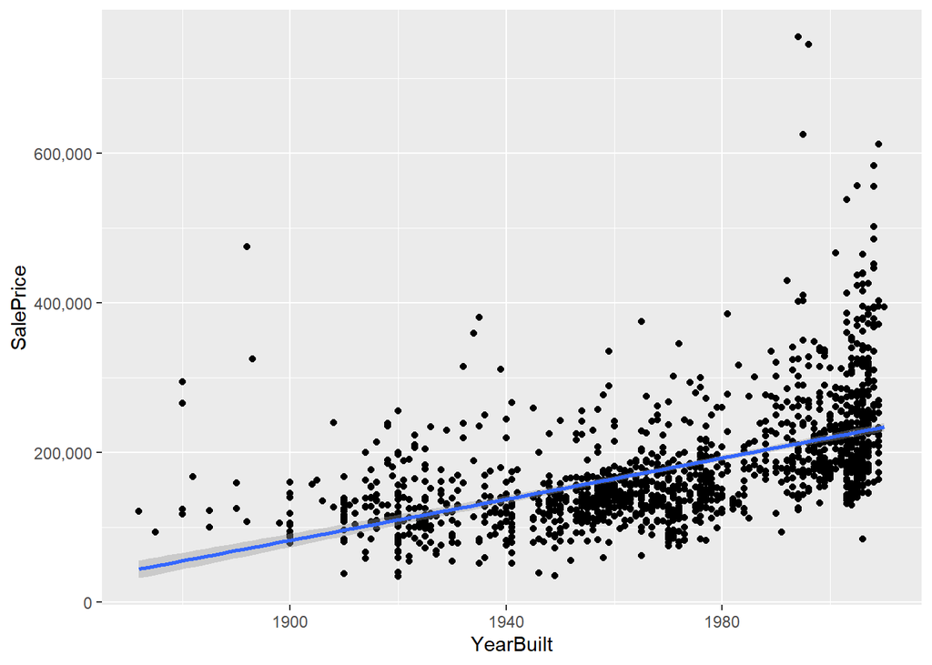

```r
ggplot(train, aes(x = YearBuilt, y = SalePrice)) +
  geom_point()+
  geom_smooth(method=lm) +
  scale_y_continuous(labels = scales::comma)
```

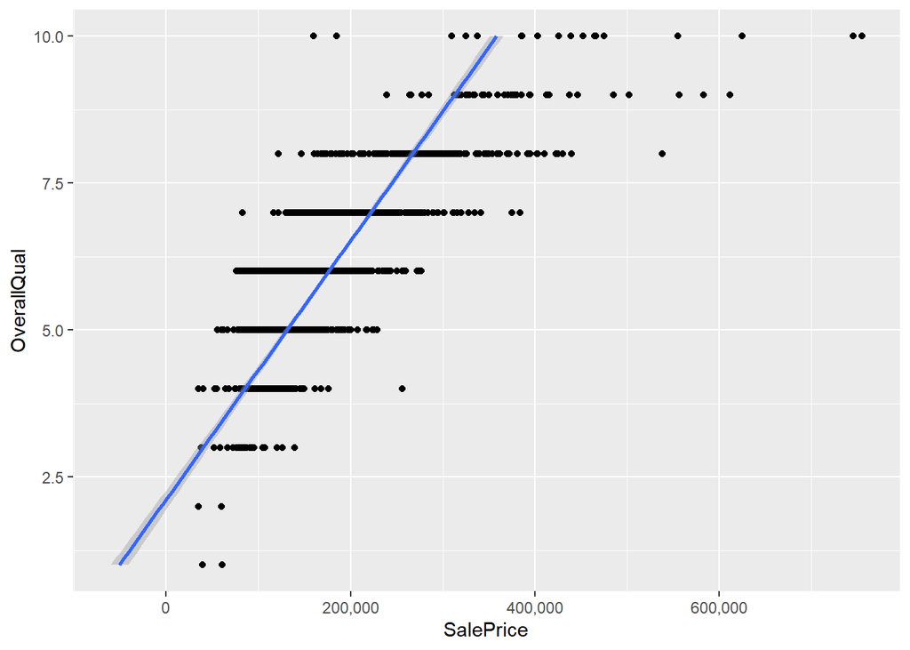

```r
ggplot(train, aes(x = OverallQual, y = SalePrice)) +
  geom_point()+
  geom_smooth(method=lm) +
  scale_y_continuous(labels = scales::comma)+coord_flip()
```

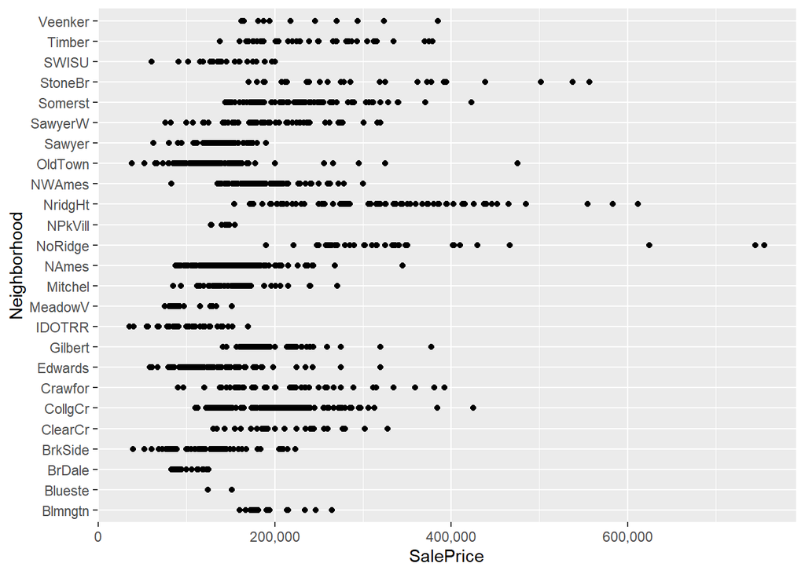

```r
ggplot(train, aes(x = Neighborhood, y = SalePrice)) +
  geom_point()+
  geom_smooth(method=lm) +
  scale_y_continuous(labels = scales::comma)+ coord_flip()
```

#### Correlation

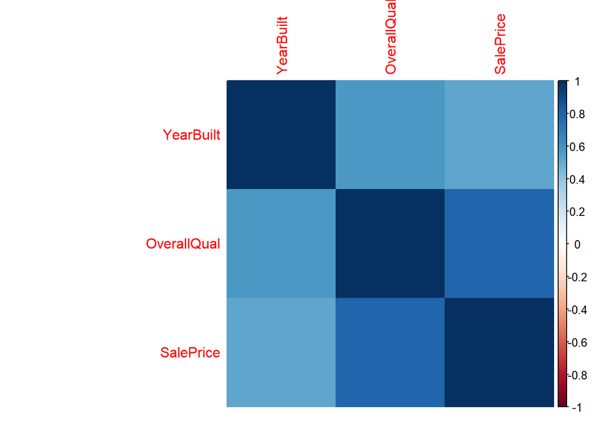

```r
data=select(train,YearBuilt,OverallQual,SalePrice)

mat=cor(data)


corrplot(mat,method ="color")
```

#### Hypothesis Testing

SalePrice and YearBuilt

```r
cor.test(train$SalePrice,train$YearBuilt, conf.level = 0.8)
```

```
##
##  Pearson's product-moment correlation
##
## data:  train$SalePrice and train$YearBuilt
## t = 23.424, df = 1458, p-value < 2.2e-16
## alternative hypothesis: true correlation is not equal to 0
## 80 percent confidence interval:
##  0.4980766 0.5468619
## sample estimates:
##       cor
## 0.5228973
```

SalePrice and OverallQual

```r
cor.test(train$SalePrice,train$OverallQual, conf.level = 0.8)
```

```
##
##  Pearson's product-moment correlation
##
## data:  train$SalePrice and train$OverallQual
## t = 49.364, df = 1458, p-value < 2.2e-16
## alternative hypothesis: true correlation is not equal to 0
## 80 percent confidence interval:
##  0.7780752 0.8032204
## sample estimates:
##       cor
## 0.7909816
```

SalePrice and FullBath

```r
cor.test(train$SalePrice,train$FullBath, conf.level = 0.8)
```

```
##
##  Pearson's product-moment correlation
##
## data:  train$SalePrice and train$FullBath
## t = 25.854, df = 1458, p-value < 2.2e-16
## alternative hypothesis: true correlation is not equal to 0
## 80 percent confidence interval:
##  0.5372107 0.5832505
## sample estimates:
##       cor
## 0.5606638
```

We can see from above examples of variables that the correlation is not equal to 0 and with 80 percent confidence that there is correlation of 0.5 and 0.55, 0.78 and 0.8, and 0.54 and 0.58 respectively.

## Linear Algebra and Correlation.

```r
pmatrix <- solve(mat)
print(pmatrix)
```

```
##              YearBuilt OverallQual  SalePrice
## YearBuilt    1.5168013  -0.6431116 -0.2844419
## OverallQual -0.6431116   2.9439846 -1.9923563
## SalePrice   -0.2844419  -1.9923563  2.7246511
```

```r
round(mat %*% pmatrix,4)
```

```
##             YearBuilt OverallQual SalePrice
## YearBuilt           1           0         0
## OverallQual         0           1         0
## SalePrice           0           0         1
```

```r
pcmat<-round(pmatrix %*% mat,4)
pcmat
```

```
##             YearBuilt OverallQual SalePrice
## YearBuilt           1           0         0
## OverallQual         0           1         0
## SalePrice           0           0         1
```

The precision matrix is an inverse of the correlation matrix, multiplying them in either direction gives us an identity matrix.

#### LU decomposition

```r
library(matrixcalc)
lu.decomposition(pcmat)
```

```
## $L
##      [,1] [,2] [,3]
## [1,]    1    0    0
## [2,]    0    1    0
## [3,]    0    0    1
##
## $U
##      [,1] [,2] [,3]
## [1,]    1    0    0
## [2,]    0    1    0
## [3,]    0    0    1
```

### Calculus-Based Probability & Statistic

```r
z <- train$TotalBsmtSF

min(z)
```

```
## [1] 0
```

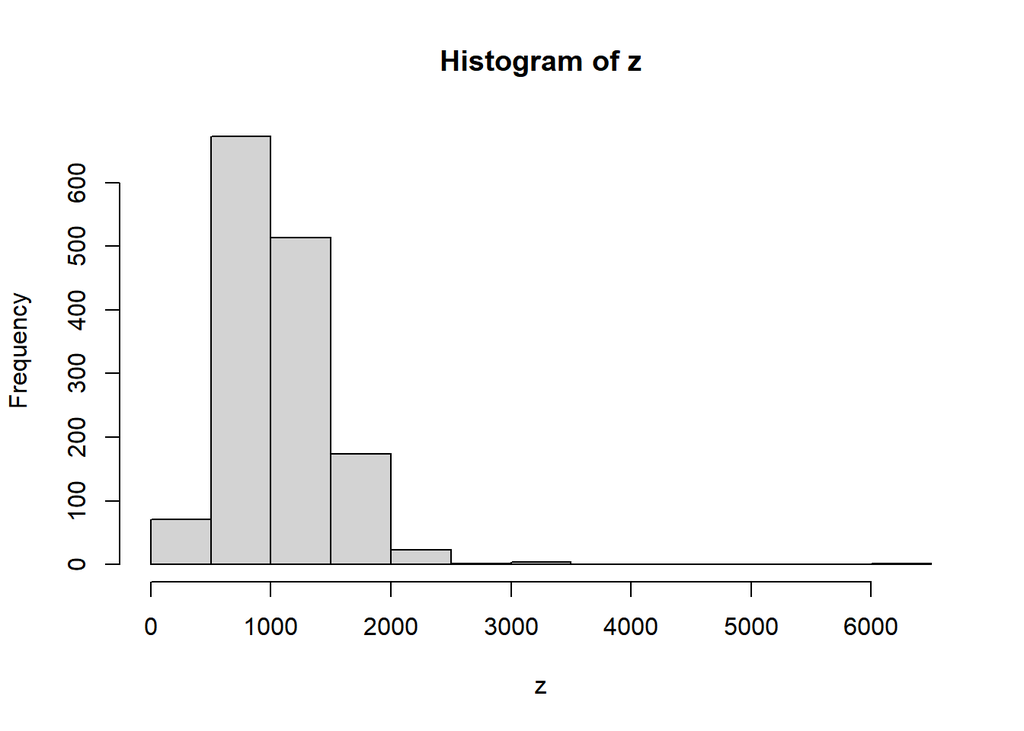

```r
hist(z)
```

Then load the MASS package and run fitdistr to fit an exponential probability density function.

```r
fit <-fitdistr(z, densfun = "exponential")
fit
```

```
##        rate
##   9.456896e-04
##  (2.474983e-05)
```

```r
fit$estimate
```

```
##         rate
## 0.0009456896
```

```r
sample<-rexp(1000, fit$estimate)
```

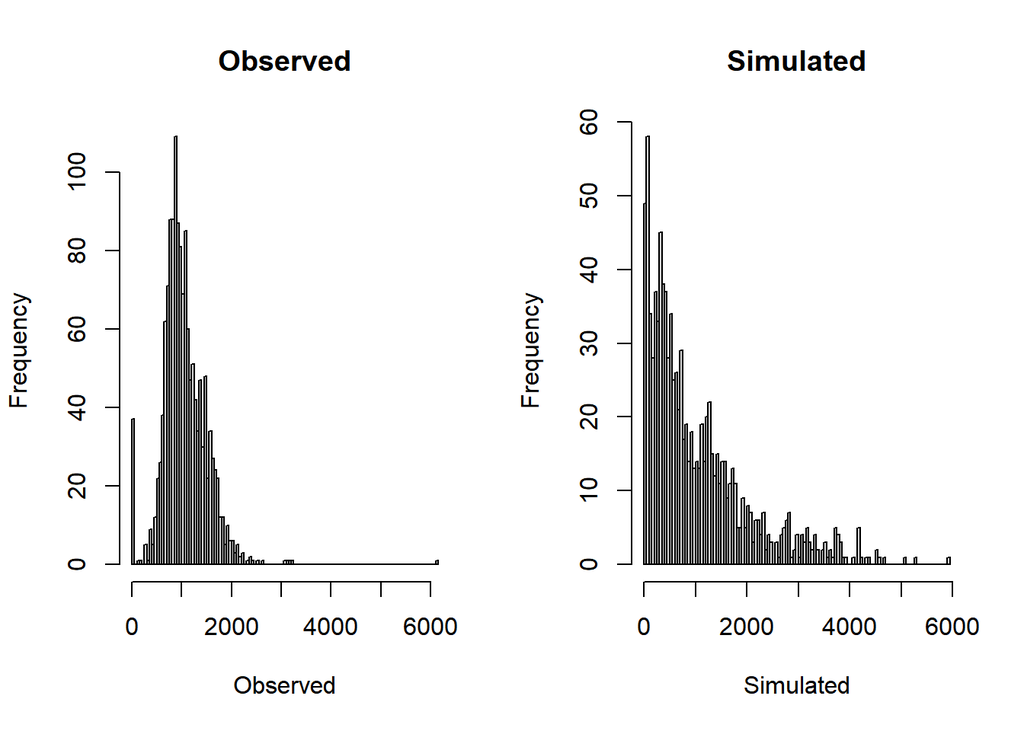

```r
par(mfrow=c(1,2))
hist(z, breaks = 100, xlab = "Observed", main = "Observed")
hist(sample, breaks = 100, xlab = "Simulated", main = "Simulated")
```

We can notice from the histograms that the simulated data is more heavily skewed to the right while the observed data is more concentrated to the center.

```r
quantile(sample, probs = c(0.05, 0.95))
```

```
##         5%        95%
##   52.02832 3197.44850
```

```r
#lower
mean(train$TotalBsmtSF ) - qnorm(0.95) * sd(train$TotalBsmtSF) / sqrt(length(train$TotalBsmtSF))
```

```
## [1] 1038.544
```

```r
#upper
mean(train$TotalBsmtSF ) + qnorm(0.95) * sd(train$TotalBsmtSF ) / sqrt(length(train$TotalBsmtSF ))
```

```
## [1] 1076.315
```

```r
quantile(train$TotalBsmtSF , probs=c(.05,.95))
```

```
##     5%    95%
##  519.3 1753.0
```

5th percentile is 519 and 95th percentile is 1753.

### Modeling

Training Data and Model Generation

```r
dt <- sapply(train, is.numeric)
dt_df <- train[ , dt]

head(dt_df)
```

```
##   Id MSSubClass LotFrontage LotArea OverallQual OverallCond YearBuilt
## 1  1         60          65    8450           7           5      2003
## 2  2         20          80    9600           6           8      1976
## 3  3         60          68   11250           7           5      2001
## 4  4         70          60    9550           7           5      1915
## 5  5         60          84   14260           8           5      2000
## 6  6         50          85   14115           5           5      1993
##   YearRemodAdd MasVnrArea BsmtFinSF1 BsmtFinSF2 BsmtUnfSF TotalBsmtSF X1stFlrSF
## 1         2003        196        706          0       150         856       856
## 2         1976          0        978          0       284        1262      1262
## 3         2002        162        486          0       434         920       920
## 4         1970          0        216          0       540         756       961
## 5         2000        350        655          0       490        1145      1145
## 6         1995          0        732          0        64         796       796
##   X2ndFlrSF LowQualFinSF GrLivArea BsmtFullBath BsmtHalfBath FullBath HalfBath
```

[output cut: 27 more lines]

```r
#Find correlation for Sale Prices

c_prices <-data.frame(apply(dt_df,2, function(col)cor(col, dt_df$SalePrice, use = "complete.obs")))
colnames(c_prices) <- c("cor")
c_prices
```

```
##                       cor
## Id            -0.02191672
## MSSubClass    -0.08428414
## LotFrontage    0.35179910
## LotArea        0.26384335
## OverallQual    0.79098160
## OverallCond   -0.07785589
## YearBuilt      0.52289733
## YearRemodAdd   0.50710097
## MasVnrArea     0.47749305
## BsmtFinSF1     0.38641981
## BsmtFinSF2    -0.01137812
## BsmtUnfSF      0.21447911
## TotalBsmtSF    0.61358055
## X1stFlrSF      0.60585218
## X2ndFlrSF      0.31933380
## LowQualFinSF  -0.02560613
## GrLivArea      0.70862448
## BsmtFullBath   0.22712223
## BsmtHalfBath  -0.01684415
## FullBath       0.56066376
## HalfBath       0.28410768
## BedroomAbvGr   0.16821315
## KitchenAbvGr  -0.13590737
## TotRmsAbvGrd   0.53372316
## Fireplaces     0.46692884
## GarageYrBlt    0.48636168
## GarageCars     0.64040920
## GarageArea     0.62343144
## WoodDeckSF     0.32441344
## OpenPorchSF    0.31585623
## EnclosedPorch -0.12857796
## X3SsnPorch     0.04458367
## ScreenPorch    0.11144657
## PoolArea       0.09240355
## MiscVal       -0.02118958
## MoSold         0.04643225
## YrSold        -0.02892259
## SalePrice      1.00000000
```

```r
(subset(c_prices, cor > 0.5))
```

```
##                    cor
## OverallQual  0.7909816
## YearBuilt    0.5228973
## YearRemodAdd 0.5071010
## TotalBsmtSF  0.6135806
## X1stFlrSF    0.6058522
## GrLivArea    0.7086245
## FullBath     0.5606638
## TotRmsAbvGrd 0.5337232
## GarageCars   0.6404092
## GarageArea   0.6234314
## SalePrice    1.0000000
```

```r
model <- lm(SalePrice ~ OverallQual + YearBuilt + YearRemodAdd + TotalBsmtSF + X1stFlrSF + GrLivArea + FullBath + TotRmsAbvGrd + GarageCars + GarageArea, data = train)

summary(model)
```

```
##
## Call:
## lm(formula = SalePrice ~ OverallQual + YearBuilt + YearRemodAdd +
##     TotalBsmtSF + X1stFlrSF + GrLivArea + FullBath + TotRmsAbvGrd +
##     GarageCars + GarageArea, data = train)
##
## Residuals:
##     Min      1Q  Median      3Q     Max
## -489958  -19316   -1948   16020  290558
##
## Coefficients:
##                Estimate Std. Error t value Pr(>|t|)
## (Intercept)  -1.186e+06  1.291e+05  -9.187  < 2e-16 ***
## OverallQual   1.960e+04  1.190e+03  16.472  < 2e-16 ***
## YearBuilt     2.682e+02  5.035e+01   5.328 1.15e-07 ***
## YearRemodAdd  2.965e+02  6.363e+01   4.659 3.47e-06 ***
## TotalBsmtSF   1.986e+01  4.295e+00   4.625 4.09e-06 ***
## X1stFlrSF     1.417e+01  4.930e+00   2.875 0.004097 **
## GrLivArea     5.130e+01  4.233e+00  12.119  < 2e-16 ***
## FullBath     -6.791e+03  2.682e+03  -2.532 0.011457 *
## TotRmsAbvGrd  3.310e+01  1.119e+03   0.030 0.976404
## GarageCars    1.042e+04  3.044e+03   3.422 0.000639 ***
## GarageArea    1.495e+01  1.031e+01   1.450 0.147384
## ---
## Signif. codes:  0 '***' 0.001 '**' 0.01 '*' 0.05 '.' 0.1 ' ' 1
##
## Residual standard error: 37920 on 1449 degrees of freedom
## Multiple R-squared:  0.7737, Adjusted R-squared:  0.7721
## F-statistic: 495.4 on 10 and 1449 DF,  p-value: < 2.2e-16
```

So the R^2 value of 0.7737, 77.37% of the variance can be explained by this model.

```r
myprediction <- predict(model,test)


DMDmodel <- data.frame( Id = test[,"Id"],  SalePrice = myprediction)
DMDmodel[DMDmodel<0] <- 0
DMDmodel <- replace(DMDmodel,is.na(DMDmodel),0)

head(DMDmodel)
```

```
##     Id SalePrice
## 1 1461  110135.9
## 2 1462  159060.0
## 3 1463  169683.7
## 4 1464  188059.7
## 5 1465  219782.0
## 6 1466  182152.0
```

```r
write.csv(DMDmodel, file="DMDmodel.csv", row.names = FALSE)
```

## Kaggle Submission - Score

Report your Kaggle.com user name and score.

Kaggle Username: hrensimin05

Kaggle Score: 0.79801

See submission documents : https://github.com/hrensimin05/Data605_FinalProject https://rpubs.com/hrensimin05/774107